# Bodové a intervalové odhady

Dominika Sónak Ballová

# Bodové a intervalové odhady

## Pre normálne rozdelenie

Predpokladajme, že životnosť batérie v hodinách sa riadi normálnym rozdelením so smerodajnou odchýlkou S(X)=1.5. Výrobca chce na základe výberového súboru určiť 99% interval v ktorom sa bude očakávaná hodnota životnosti nachádzať.

```r
ziv <- c(18.3,19.6,18.6,19.4,17,18.5,18,18.4,19,20.2)
n <- length(ziv)
mean(ziv)  # bodový odhad
```

```
## [1] 18.7
```

```r
zivmean <- mean(ziv)
zivmean + c(-1,1)*qnorm(1-0.01/2)*1.5/sqrt(n)  # 99% IS pri znamom sigma (SD)
```

```
## [1] 17.47818 19.92182
```

```r
# v praxi je sd malokedy znama
zivsd <- sd(ziv) # odhad sd
zivmean + c(-1,1) * qt(1-0.01/2, n-1) * zivsd/sqrt(n)
```

```
## [1] 17.77318 19.62682
```

```r
t.test(ziv,conf.level = 0.99)$conf.int
```

```
## [1] 17.77318 19.62682
## attr(,"conf.level")
## [1] 0.99
```

```r
t.test(ziv,conf.level = 0.99, alternative = "greater")$conf.int
```

```
## [1] 17.89535      Inf
## attr(,"conf.level")
## [1] 0.99
```

```r
t.test(ziv,conf.level = 0.99, alternative = "less")$conf.int
```

```
## [1]     -Inf 19.50465
## attr(,"conf.level")
## [1] 0.99
```

Už vieme, že priemer nie je vždy najlepšou charakteristikou. Pre medián budeme interval spoľahlivosti popisovať pri neparametrických testoch.

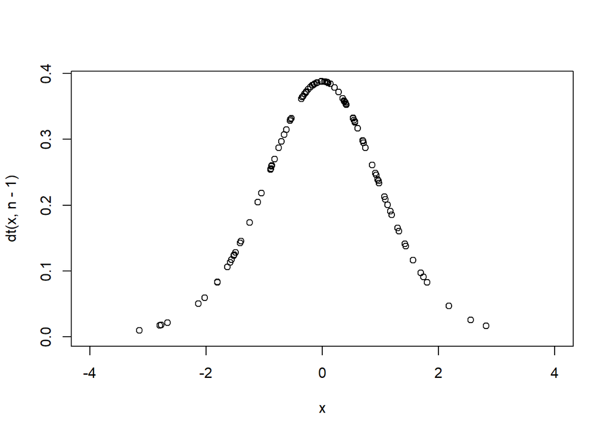

```r
x<-rt(100, n-1)
plot(x,dt(x,n-1),xlim = c(-4,4))
```

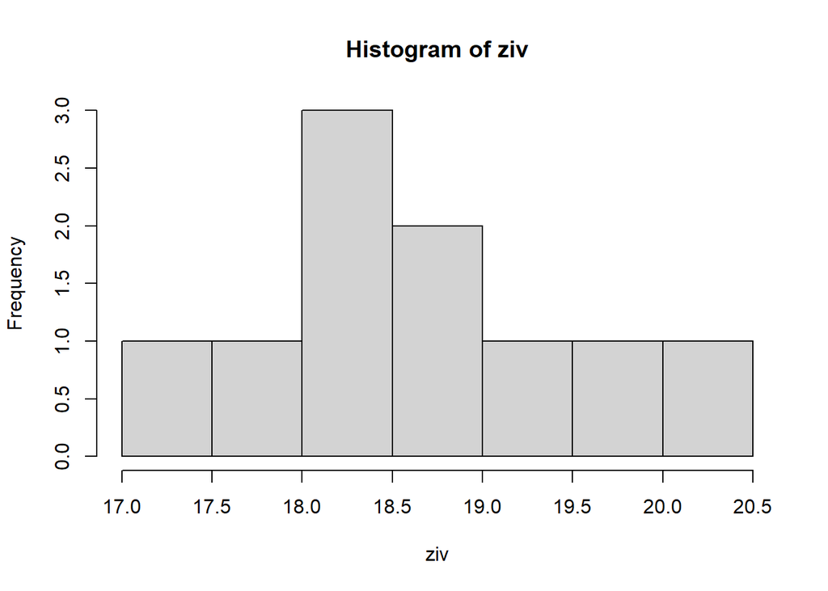

```r
hist(ziv)
```

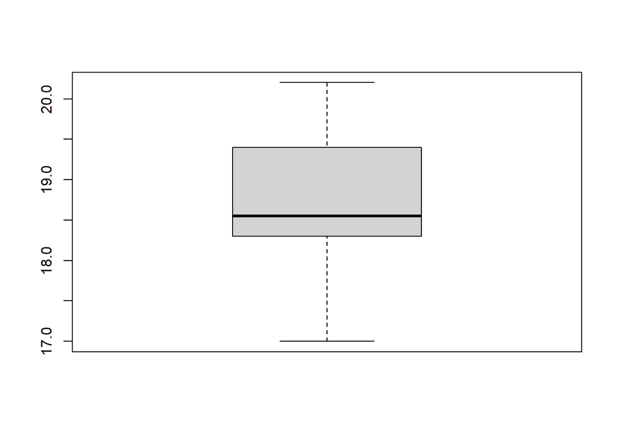

```r
boxplot(ziv)
```

```r
# odhad rozptylu
s2<-var(ziv)
IS<-c((n-1)*s2/qchisq(1-0.01/2,n-1),(n-1)*s2/qchisq(0.01/2,n-1))
IS
```

```
## [1] 0.3103095 4.2191833
```

```r
library(EnvStats)
varTest(ziv, alternative = "two.sided", conf.level = .99)$conf.int
```

```
##       LCL       UCL
## 0.3103095 4.2191833
## attr(,"conf.level")
## [1] 0.99
```

```r
c((n-1)*s2/qchisq(1-0.01, n-1), Inf ) # ĽS IS
```

```
## [1] 0.3378566       Inf
```

```r
varTest(ziv, alternative = "greater", conf.level = .99)$conf.int
```

```
##       LCL       UCL
## 0.3378566       Inf
## attr(,"conf.level")
## [1] 0.99
```

```r
c(0, (n-1)*s2/qchisq(0.01, n-1)) # PS IS
```

```
## [1] 0.000000 3.505914
```

```r
varTest(ziv, alternative = "less", conf.level = .99)$conf.int
```

```
##      LCL      UCL
## 0.000000 3.505914
## attr(,"conf.level")
## [1] 0.99
```

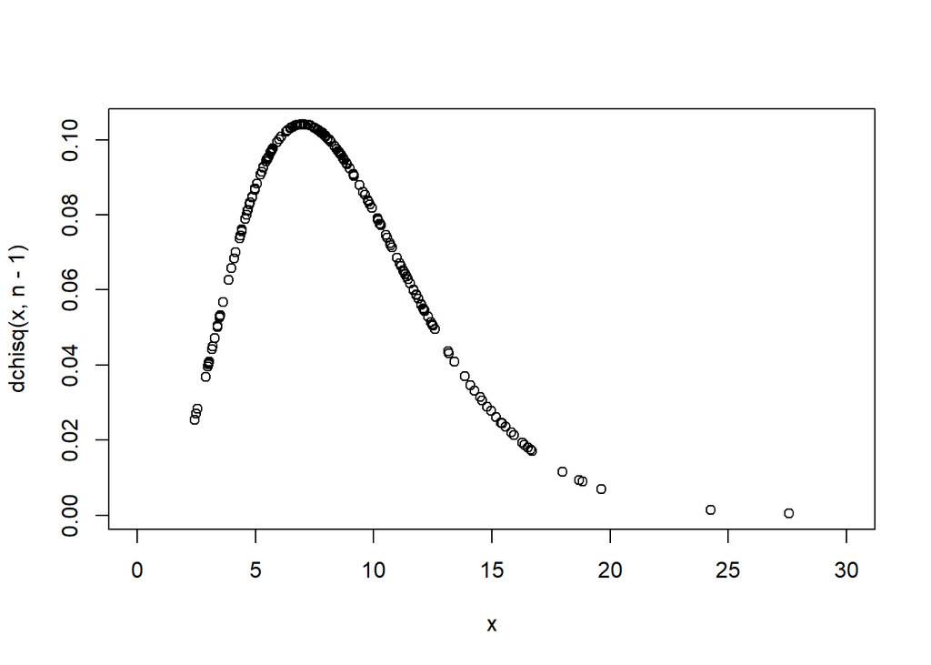

```r
# hustota chi2 rozdelenia
x<-rchisq(200,n-1)
plot(x, dchisq(x,n-1),xlim = c(0,30))
```

# Proporcia

Niekedy chceme odhadnúť podiel výskytu nejakého javu- proporciu.

```r
p<-78/100 # bodový odhad
prop.test(78, 100, conf.level = .95)$conf.int
```

```
## [1] 0.6838686 0.8541734
## attr(,"conf.level")
## [1] 0.95
```

# Príklady

## Kopírka

Výrobca uvádza, že v kopírke je nutné vymeniť toner priemerne o 2500 skopírovaných stranách so smerodajnou odchýlkou 30 strán. Počas roka boli namerané nasledujúce hodnoty: xi: 2448, 2482, 2485, 2489, 2506, 2514, 2516, 2533, 2553, 2586, 2590 ni: 2,3,4,6,8,9,6,5,4,2,1 Predpokladajme, že dáta sú normálne rozdelené. Nájdite 95% IS pre strednú hodnotu, smerodajná odchýlka je 30. Nájdite 95% IS pre strednú hodnotu, ak smerodajnú odchýlku nepoznáme. Nájdite 95% IS pre rozptyl. Nájdite obojstranné a ľavostranné IS pre dané úlohy.

## Vápnik

Presnosť metódy analýzy na obsah vápnika je daná smerodajnou odchýkou σ = 0.12%. Vykonali sme 6 skúšok a zistili sme výberový priemer x¯ = 32.56%. Určte: 95 %-ný obojstranný interval spoľahlivosti pre obsah vápnika, 95 %-ný ľavostranný interval spoľahlivosti pre obsah vápnika, 95 %-ný pravostranný interval spoľahlivosti pre obsah vápnika.

## Batéria

Výdrž notebooku na batériu závisí na jej kapacite, výbave notebooku a náročnosti použitia. Počas 30 rovnako náročných pracovných cyklov do vybitia batérie sme zisťovali dobu jej činnosti v minútach. 272, 182, 274, 349, 240, 265, 204, 264, 255, 243, 245,301, 260, 282, 223, 278, 211, 163, 253, 244, 233, 251,254, 248, 248, 207, 252, 259, 230, 221 urobte prvotnú štatistickú analýzu - výpočtovú a grafickú